# Weather Modeling

davegoblue

6/18/2020

## Background

The file ‘WeatherEDA_202005_v002.Rmd’ contains exploratory data analysis for historical weather data as contained in METAR archives hosted by Iowa State University.

Data have been dowloaded, processed, cleaned, and integrated for several stations (airports) and years, with .rds files saved in “./RInputFiles/ProcessedMETAR”.

This module will perform initial modeling on the processed weather files.

#### *Data Availability*

There are three main processed files available for further exploration:

*metar_postEDA_20200617.rds*

- source (chr) - the reporting station and time
- locale (chr) - the descriptive name for source
- dtime (dttm) - the date-time for the observation
- origMETAR (chr) - the original METAR associated with the observation at that source and date-time
- year (dbl) - the year, extracted from dtime
- monthint (dbl) - the month, extracted from dtime, as an integer
- month (fct) - the month, extracted from dtime, as a three-character abbreviation (factor)
- day (int) - the day of the month, extracted from dtime
- WindDir (chr) - previaling wind direction in degrees, stored as a character since ‘VRB’ means variable
- WindSpeed (int) - the prevailing wind speed in knots
- WindGust (dbl) - the wind gust speed in knots (NA if there is no recorded wind gust at that hour)
- predomDir (chr) - the predominant wind direction as NE-E-SE-S-SW-W-NW-N-VRB-000-Error
- Visibility (dbl) - surface visibility in statute miles
- Altimeter (dbl) - altimeter in inches of mercury
- TempF (dbl) - the Fahrenheit temperature
- DewF (dbl) - the Fahrenheit dew point
- modSLP (dbl) - Sea-Level Pressure (SLP), adjusted to reflect that SLP is recorded as 0-1000 but reflects data that are 950-1050
- cTypen (chr) - the cloud type of the nth cloud layer (FEW, BKN, SCT, OVC, or VV)
- cLeveln (dbl) - the cloud height in feet of the nth cloud layer
- isRain (lgl) - was rain occurring at the moment the METAR was captured?
- isSnow (lgl) - was snow occurring at the moment the METAR was captured?
- isThunder (lgl) - was thunder occurring at the moment the METAR was captured?
- p1Inches (dbl) - how many inches of rain occurred in the past hour?
- p36Inches (dbl) - how many inches of rain occurred in the past 3/6 hours (3-hour summaries at 3Z-9Z-15Z-21Z and 6-hour summaries at 6Z-12Z-18Z-24Z and NA at any other Z times)?
- p24Inches (dbl) - how many inches of rain occurred in the past 24 hours (at 12Z, NA at all other times)
- tempFHi (dbl) - the high temperature in the past 24 hours, in Fahrenheit (reported once per day)
- tempFLo (dbl) - the low temperature in the past 24 hours, in Fahrenheit (reported once per day)
- minHeight (dbl) - the minimum cloud height in feet (-100 means ‘no clouds’)
- minType (fct) - amount of obscuration at the minimum cloud height (VV > OVC > BKN > SCT > FEW > CLR)
- ceilingHeight (dbl) - the minimum cloud ceiling in feet (-100 means ‘no ceiling’)
- ceilingType (fct) - amount of obscuration at the minimum ceiling height (VV > OVC > BKN)

*metar_modifiedClouds_20200617.rds*

- source (chr) - the reporting station and time
- sourceName (chr) - the descriptive name for source
- dtime (dttm) - the date-time for the observation
- level (dbl) - cloud level (level 0 is inserted for every source-dtime as a base layer of clear)
- height (dbl) - level height (height -100 is inserted for every source-dtime as a base layer of clear)
- type (dbl) - level type (type CLR is inserted for every source-dtime as a base layer of clear)

*metar_precipLists_20200617.rds*

- Contains elements for each of rain/snow/thunder for each of 2015/2016/2017
- Each element contains a list and a tibble
- The tibble is precipLength and contains precipitation by month as source-locale-month-hours-events
- The list is precipList and contains data on each precipitation interval

Glimpses of the three main files are as follows:

```r
# The tidyverse library will be used throughout
library(tidyverse)
# Main weather data
metarData <- readRDS("./RInputFiles/ProcessedMETAR/metar_postEDA_20200617.rds")
glimpse(metarData)
```

```
## Observations: 201,216
## Variables: 41
## $ source        <chr> "kdtw_2016", "kdtw_2016", "kdtw_2016", "kdtw_2016", "...
## $ locale        <chr> "Detroit, MI (2016)", "Detroit, MI (2016)", "Detroit,...
## $ dtime         <dttm> 2016-01-01 00:53:00, 2016-01-01 01:53:00, 2016-01-01...
## $ origMETAR     <chr> "KDTW 010053Z 23012KT 10SM OVC020 00/M05 A3021 RMK AO...
## $ year          <dbl> 2016, 2016, 2016, 2016, 2016, 2016, 2016, 2016, 2016,...
## $ monthint      <dbl> 1, 1, 1, 1, 1, 1, 1, 1, 1, 1, 1, 1, 1, 1, 1, 1, 1, 1,...
## $ month         <fct> Jan, Jan, Jan, Jan, Jan, Jan, Jan, Jan, Jan, Jan, Jan...
## $ day           <int> 1, 1, 1, 1, 1, 1, 1, 1, 1, 1, 1, 1, 1, 1, 1, 1, 1, 1,...
## $ WindDir       <chr> "230", "230", "230", "240", "230", "220", "220", "220...
## $ WindSpeed     <int> 12, 12, 11, 14, 16, 13, 14, 16, 13, 16, 17, 13, 15, 1...
## $ WindGust      <dbl> NA, NA, NA, 23, 22, NA, 20, 20, NA, 22, NA, NA, 22, 2...
## $ predomDir     <fct> SW, SW, SW, SW, SW, SW, SW, SW, SW, SW, SW, SW, SW, S...
## $ Visibility    <dbl> 10, 10, 10, 10, 10, 10, 10, 10, 8, 5, 7, 8, 10, 10, 7...
```

[output cut: 28 more lines]

```r
# Extra clouds data
cloudData <- readRDS("./RInputFiles/ProcessedMETAR/metar_modifiedClouds_20200617.rds")
glimpse(cloudData)
```

```
## Observations: 393,258
## Variables: 6
## $ source     <chr> "kdtw_2016", "kdtw_2016", "kdtw_2016", "kdtw_2016", "kdt...
## $ sourceName <chr> "Detroit, MI (2016)", "Detroit, MI (2016)", "Detroit, MI...
## $ dtime      <dttm> 2016-01-01 00:53:00, 2016-01-01 00:53:00, 2016-01-01 01...
## $ level      <dbl> 0, 1, 0, 1, 0, 1, 0, 1, 0, 1, 0, 1, 0, 1, 0, 1, 0, 1, 0,...
## $ height     <dbl> -100, 2000, -100, 2000, -100, 2200, -100, 2500, -100, 27...
## $ type       <fct> CLR, OVC, CLR, OVC, CLR, OVC, CLR, OVC, CLR, OVC, CLR, O...
```

```r
# Precipitation summaries
precipData <- readRDS("./RInputFiles/ProcessedMETAR/metar_precipLists_20200617.rds")
names(precipData)
```

```
## [1] "rain2015"    "rain2016"    "rain2017"    "snow2015"    "snow2016"
## [6] "snow2017"    "thunder2015" "thunder2016" "thunder2017"
```

```r
names(precipData$rain2016)
```

```
## [1] "precipList"   "precipLength"
```

```r
names(precipData$rain2016$precipList)
```

```
##  [1] "kdtw_2016_RA" "kewr_2016_RA" "kgrb_2016_RA" "kgrr_2016_RA" "kiah_2016_RA"
##  [6] "kind_2016_RA" "klas_2016_RA" "klnk_2016_RA" "kmke_2016_RA" "kmsn_2016_RA"
## [11] "kmsp_2016_RA" "kmsy_2016_RA" "kord_2016_RA" "ksan_2016_RA" "ktvc_2016_RA"
```

```r
names(precipData$rain2016$precipList$kdtw_2016_RA)
```

```
## [1] "pStateFrame"      "pIssueTimes"      "mismatches"       "mismatchTimes"
## [5] "beginEndInterval"
```

```r
glimpse(precipData$rain2016$precipLength)
```

```
## Observations: 180
## Variables: 5
## $ source <chr> "kdtw_2016", "kdtw_2016", "kdtw_2016", "kdtw_2016", "kdtw_20...
## $ locale <chr> "Detroit, MI (2016)", "Detroit, MI (2016)", "Detroit, MI (20...
## $ month  <fct> Jan, Feb, Mar, Apr, May, Jun, Jul, Aug, Sep, Oct, Nov, Dec, ...
## $ hours  <dbl> 27.928889, 20.828333, 77.274722, 73.072778, 46.488611, 20.12...
## $ events <dbl> 16, 18, 31, 38, 41, 31, 31, 40, 49, 29, 41, 21, 20, 41, 30, ...
```

```r
glimpse(precipData$rain2016$precipList$kdtw_2016_RA)
```

```
## List of 5
##  $ pStateFrame     :Classes 'tbl_df', 'tbl' and 'data.frame':    8818 obs. of  5 variables:
##   ..$ origMETAR: chr [1:8818] "KDTW 310053Z 23007KT 10SM BKN025 OVC050 02/M03 A3017 RMK AO2 SLP223 T00221033" "KDTW 310153Z 22009KT 10SM OVC021 02/M03 A3019 RMK AO2 SLP229 T00221028" "KDTW 310253Z 24009KT 10SM OVC021 02/M03 A3018 RMK AO2 SLP224 T00171028 50004" "KDTW 310353Z 24010KT 10SM OVC025 0…
##   ..$ dtime    : POSIXct[1:8818], format: "2015-12-31 00:53:00" "2015-12-31 01:53:00" ...
##   ..$ strPrecip: chr [1:8818] NA NA NA NA ...
##   ..$ curPrecip: logi [1:8818] FALSE FALSE FALSE FALSE FALSE FALSE ...
##   ..$ lagPrecip: logi [1:8818] NA FALSE FALSE FALSE FALSE FALSE ...
##  $ pIssueTimes     :Classes 'tbl_df', 'tbl' and 'data.frame':    7 obs. of  1 variable:
##   ..$ dtime: POSIXct[1:7], format: "2016-02-24 11:53:00" "2016-04-01 00:53:00" ...
##  $ mismatches      : int(0)
##  $ mismatchTimes   : 'POSIXct' num(0)
##  - attr(*, "tzone")= chr "UTC"
##  $ beginEndInterval:Classes 'tbl_df', 'tbl' and 'data.frame':    387 obs. of  3 variables:
##   ..$ beginTimes: POSIXct[1:387], format: "2015-12-31 17:45:00" "2016-01-08 16:27:00" ...
##   ..$ endTime   : POSIXct[1:387], format: "2015-12-31 17:53:00" "2016-01-09 00:13:00" ...
##   ..$ precipInts:Formal class 'Interval' [package "lubridate"] with 3 slots
```

#### *Helpers - Functions and Mappings*

There are a few functions and mappings that can help with the modeling process:

```r
# The process frequently uses tidyverse and lubridate
library(tidyverse)
library(lubridate)
```

```r
# The main path for the files
filePath <- "./RInputFiles/ProcessedMETAR/"


# Descriptive names for key variables
varMapper <- c(source="Original source file name",
               locale="Descriptive name",
               dtime="Date-Time (UTC)",
               origMETAR="Original METAR",
               year="Year",
               monthint="Month",
               month="Month",
               day="Day of Month",
               WindDir="Wind Direction (degrees)",
               WindSpeed="Wind Speed (kts)",
               WindGust="Wind Gust (kts)",
               predomDir="General Prevailing Wind Direction",
               Visibility="Visibility (SM)",
               Altimeter="Altimeter (inches Hg)",
               TempF="Temperature (F)",
               DewF="Dew Point (F)",
               modSLP="Sea-Level Pressure (hPa)",
               cType1="First Cloud Layer Type",
               cLevel1="First Cloud Layer Height (ft)",
               isRain="Rain at Observation Time",
               isSnow="Snow at Observation Time",
               isThunder="Thunder at Obsevation Time",
               tempFHi="24-hour High Temperature (F)",
               tempFLo="24-hour Low Temperature (F)",
               minHeight="Minimum Cloud Height (ft)",
               minType="Obscuration Level at Minimum Cloud Height",
               ceilingHeight="Minimum Ceiling Height (ft)",
               ceilingType="Obscuration Level at Minimum Ceiling Height",
               hr="Hour of Day (Zulu time)"
               )


# File name to city name mapper
cityNameMapper <- c(kdtw_2016="Detroit, MI (2016)",
                    kewr_2016="Newark, NJ (2016)",
                    kgrb_2016="Green Bay, WI (2016)",
                    kgrr_2016="Grand Rapids, MI (2016)",
                    kiah_2016="Houston, TX (2016)",
                    kind_2016="Indianapolis, IN (2016)",
                    klas_2015="Las Vegas, NV (2015)",
                    klas_2016="Las Vegas, NV (2016)",
                    klas_2017="Las Vegas, NV (2017)",
                    klnk_2016="Lincoln, NE (2016)",
                    kmke_2016="Milwaukee, WI (2016)",
                    kmsn_2016="Madison, WI (2016)",
                    kmsp_2016="Minneapolis, MN (2016)",
                    kmsy_2015="New Orleans, LA (2015)",
                    kmsy_2016="New Orleans, LA (2016)",
                    kmsy_2017="New Orleans, LA (2017)",
                    kord_2015="Chicago, IL (2015)",
                    kord_2016="Chicago, IL (2016)",
                    kord_2017="Chicago, IL (2017)",
                    ksan_2015="San Diego, CA (2015)",
                    ksan_2016="San Diego, CA (2016)",
                    ksan_2017="San Diego, CA (2017)",
                    ktvc_2016="Traverse City, MI (2016)"
                    )
```

#### *Initial Exploration*

The caret package allows for many types of models to be called on the data.

A function is written to subset the data and create appropriate train-test splits:

```r
# Create test and train data, filtered for locales and months, and keeping only relevant variables
createTestTrain <- function(df,
                            sources=NULL,
                            vrbls=NULL,
                            convFactor="locale",
                            months=1:12,
                            testSize=0.3,
                            noNA=TRUE,
                            seed=NULL
                            ) {

    # FUNCTION ARGUMENTS:
    # df: the data frame or tibble containing the data
    # sources: the source records to be included (NULL will include all)
    # vrbls: the variables to be included (NULL will include all)
    # convFactor: variable to convert to a factor after processing (NULL for none)
    # months: the months to be included
    # testSize: the fraction of observations to be included as test
    # seed: the seed for reproducibility

    # Set the seed if it has been passed
    if (!is.null(seed)) { set.seed(seed) }

    # Set sources to be all sources if NULL
    if (is.null(sources)) {
        sources <- df %>%
            count(source) %>%
            pull(source)
    }

    # Set vrbls to be all variables if NULL
    if (is.null(vrbls)) { vrbls <- names(df) }

    # Filter the data for the relevant sources and months, and limit to vars
    dfMod <- df %>%
        filter(source %in% sources, monthint %in% months) %>%
        select_at(vars(all_of(vrbls)))

    # Use only complete cases if noNA=TRUE
    if (noNA) {
        dfMod <- dfMod %>%
            filter(complete.cases(dfMod))
    }

    # Convert the key variable to a factor if requested
    if (!is.null(convFactor)) {
        dfMod <- dfMod %>%
            mutate_at(vars(all_of(convFactor)), factor)
    }

    # Split in to test and train (do not sort so that records by locale do not end up in any given order)
    idx <- sample(1:nrow(dfMod), round((1-testSize) * nrow(dfMod)), replace=FALSE)

    # Return the test and train data
    list(testData=dfMod[-idx, ],
         trainData=dfMod[idx, ]
         )

}
```

As an example, data for 2016 are pulled for two of the cities - Las Vegas and New Orleans:

```r
ttLists <- createTestTrain(metarData,
                           sources=c("klas_2016", "kmsy_2016"),
                           vrbls=c("locale", "month", "predomDir", "TempF", "DewF", "Altimeter", "modSLP"),
                           seed=2006181356
                           )
ttLists
```

```
## $testData
## # A tibble: 5,246 x 7
##    locale               month predomDir TempF  DewF Altimeter modSLP
##    <fct>                <fct> <fct>     <dbl> <dbl>     <dbl>  <dbl>
##  1 Las Vegas, NV (2016) Jan   NE         37.0  8.06      30.2  1024
##  2 Las Vegas, NV (2016) Jan   NE         35.1  8.96      30.2  1024
##  3 Las Vegas, NV (2016) Jan   S          30.0  8.96      30.2  1024.
##  4 Las Vegas, NV (2016) Jan   S          27.0  8.06      30.2  1025.
##  5 Las Vegas, NV (2016) Jan   S          28.9  8.06      30.2  1025.
##  6 Las Vegas, NV (2016) Jan   S          37.9 12.0       30.2  1023.
##  7 Las Vegas, NV (2016) Jan   000        39.0 12.9       30.2  1023.
##  8 Las Vegas, NV (2016) Jan   NE         42.1 12.9       30.2  1022.
##  9 Las Vegas, NV (2016) Jan   000        41   12.9       30.2  1022.
## 10 Las Vegas, NV (2016) Jan   N          51.1 18.0       30.2  1021.
## # ... with 5,236 more rows
##
## $trainData
## # A tibble: 12,242 x 7
##    locale                 month predomDir TempF  DewF Altimeter modSLP
##    <fct>                  <fct> <fct>     <dbl> <dbl>     <dbl>  <dbl>
##  1 Las Vegas, NV (2016)   Jul   SW        102.   21.9      29.7  1004
##  2 New Orleans, LA (2016) Aug   SW         78.1  73.9      29.9  1012.
##  3 New Orleans, LA (2016) May   E          81.0  72.0      29.9  1012.
##  4 Las Vegas, NV (2016)   Dec   000        61.0  36.0      30.0  1017.
##  5 New Orleans, LA (2016) Dec   VRB        62.1  57.0      30.1  1019.
##  6 New Orleans, LA (2016) Mar   S          72.0  59        30.0  1016
##  7 Las Vegas, NV (2016)   Apr   S          75.0  12.0      29.8  1008.
##  8 Las Vegas, NV (2016)   Nov   S          62.1  23        29.9  1011.
##  9 Las Vegas, NV (2016)   Dec   S          37.0  25.0      30.4  1030.
## 10 New Orleans, LA (2016) Aug   E          93.9  75.0      30.0  1016.
## # ... with 12,232 more rows
```

A simple random forest can then be applied to the data, with several options for complexity:

```r
# Create a tuning grid and run the models
trGrid <- expand.grid(min.node.size=c(1, 5, 10, 25, 100),
                      mtry=c(1, 2, 3, 4, 5, 6),
                      splitrule=c("gini")
                      )

caretModel <- caret::train(locale ~ .,
                           data=ttLists$trainData,
                           method="ranger",
                           tuneGrid=trGrid,
                           trControl=caret::trainControl(method="cv", number=5),
                           num.trees=50
                           )
caretModel
```

```
## Random Forest
##
## 12242 samples
##     6 predictor
##     2 classes: 'Las Vegas, NV (2016)', 'New Orleans, LA (2016)'
##
## No pre-processing
## Resampling: Cross-Validated (5 fold)
## Summary of sample sizes: 9793, 9793, 9795, 9793, 9794
## Resampling results across tuning parameters:
##
##   min.node.size  mtry  Accuracy   Kappa
##     1            1     0.8427581  0.6855732
##     1            2     0.9449438  0.8898891
##     1            3     0.9732885  0.9465764
```

[output cut: 32 more lines]

The model is not worried about over-fitting, choosing the smallest minimum node size and the largest mrty. How well does this model work on the test data?

```r
# Run the best parameters from ranger in randomForest
caretBest <- randomForest::randomForest(locale ~ .,
                                        data=ttLists$trainData,
                                        ntree=50,
                                        nodesize=1,
                                        mtry=6
                                        )
caretBest
```

```
##
## Call:
##  randomForest(formula = locale ~ ., data = ttLists$trainData,      ntree = 50, nodesize = 1, mtry = 6)
##                Type of random forest: classification
##                      Number of trees: 50
## No. of variables tried at each split: 6
##
##         OOB estimate of  error rate: 1.47%
## Confusion matrix:
##                        Las Vegas, NV (2016) New Orleans, LA (2016) class.error
## Las Vegas, NV (2016)                   6034                     95  0.01550008
## New Orleans, LA (2016)                   85                   6028  0.01390479
```

The model estimates an OOB error rate of between 1%-2%, suggesting a strong ability to differentiate Las Vegas from New Orleans.

A function is built to assess performance on the test data:

```r
# Predictions and confusion matrices on test data
evalPredictions <- function(model,
                            testData,
                            printAll=TRUE,
                            printCM=printAll,
                            printConfSummary=printAll,
                            printConfTable=printAll,
                            showPlots=TRUE
                            ) {

    # FUNCTION ARGUMENTS:
    # model: a trained model
    # testData: the test data to apply the model against
    # printAll: whether to print the text summaries (by default, carries to the next three arguments)
    # printCM: whether to print the confusion matrix
    # printConfSummary: whether to print the voting summary (rough proxy for confidence) of the predictions
    # printConfTable: whether to summarize the accuracy by voting summary
    # showPlots: whether to display plots related to the outputs

    # Get the predicted class and probabilities
    testClass <- predict(model, newdata=testData)
    testProbs <- predict(model, newdata=testData, type="prob")
    if (printCM) {
        print(caret::confusionMatrix(testClass, testData$locale))
    }

    # Create a tibble containing class prediction, maximum probability, and individual predictions
    tblProbs <- tibble::as_tibble(testProbs) %>%
        mutate(maxProb=apply(., 1, FUN=max),
               sumProb=apply(., 1, FUN=sum),
               predClass=testClass,
               locale=testData$locale,
               accurate=(predClass==locale)
               )

    # Describe the maximum probability by source
    if (printConfSummary) {
        tblProbs %>%
            group_by(locale) %>%
            summarize(meanMax=mean(maxProb), medianMax=median(maxProb),
                      pct90Plus=mean(maxProb > 0.9), pct50Minus=mean(maxProb < 0.5)
                      ) %>%
        print()
    }

    # Create a table of accuracy by source and prediction confidence
    p1Data <- tblProbs %>%
        mutate(predProb=0.5 * round(2*maxProb, 1)) %>%
        group_by(predProb, locale) %>%
        summarize(pctCorrect=mean(accurate), nCorrect=sum(accurate), nObs=n())

    p1Print <- p1Data %>%
        group_by(predProb) %>%
        summarize(nCorrect=sum(nCorrect), nObs=sum(nObs)) %>%
        mutate(pctCorrect=nCorrect/nObs)
    if (printConfTable) {
        print(p1Print)
    }

    cat("\nMean Error-Squared Between Confidence of Prediction and Accuracy of Precition\n")
    p1Print %>%
        mutate(err2=nObs*(pctCorrect-predProb)**2) %>%
        summarize(meanError2=sum(err2)/sum(nObs)) %>%
        print()

    # Plot the maximum probability forecasted by row
    p1 <- p1Data %>%
        ggplot(aes(x=predProb)) +
        geom_col(aes(y=nObs, fill=locale)) +
        labs(x="Maximum probability predicted", y="# Observations",
             title="Count of Maximum Probability Predicted by Locale"
             )
    p2 <- p1Data %>%
        ggplot(aes(x=predProb)) +
        geom_line(aes(y=pctCorrect, group=locale, color=locale)) +
        geom_abline(aes(intercept=0, slope=1), lty=2) +
        ylim(c(0, 1)) +
        labs(x="Maximum probability predicted", y="Actual Probability Correct",
             title="Accuracy of Maximum Probability Predicted by Locale"
             )

    if (showPlots) {
        print(p1)
        print(p2)
    }

    tblProbs

}
```

And the function is then run for the Las Vegas and New Orleans data:

```r
evalPredictions(caretBest, testData=ttLists$testData)
```

```
## Confusion Matrix and Statistics
##
##                         Reference
## Prediction               Las Vegas, NV (2016) New Orleans, LA (2016)
##   Las Vegas, NV (2016)                   2578                     27
##   New Orleans, LA (2016)                   28                   2613
##
##                Accuracy : 0.9895
##                  95% CI : (0.9864, 0.9921)
##     No Information Rate : 0.5032
##     P-Value [Acc > NIR] : <2e-16
##
##                   Kappa : 0.979
##
##  Mcnemar's Test P-Value : 1
##
##             Sensitivity : 0.9893
##             Specificity : 0.9898
##          Pos Pred Value : 0.9896
##          Neg Pred Value : 0.9894
##              Prevalence : 0.4968
##          Detection Rate : 0.4914
##    Detection Prevalence : 0.4966
##       Balanced Accuracy : 0.9895
##
##        'Positive' Class : Las Vegas, NV (2016)
##
## # A tibble: 2 x 5
##   locale                 meanMax medianMax pct90Plus pct50Minus
##   <fct>                    <dbl>     <dbl>     <dbl>      <dbl>
## 1 Las Vegas, NV (2016)     0.978         1     0.923          0
## 2 New Orleans, LA (2016)   0.983         1     0.939          0
## # A tibble: 11 x 4
##    predProb nCorrect  nObs pctCorrect
##       <dbl>    <int> <int>      <dbl>
##  1     0.5        11    20      0.55
##  2     0.55       10    21      0.476
##  3     0.6        14    20      0.7
##  4     0.65       13    18      0.722
##  5     0.7        34    43      0.791
##  6     0.75       29    33      0.879
##  7     0.8        50    52      0.962
##  8     0.85       55    55      1
##  9     0.9       152   157      0.968
## 10     0.95      193   196      0.985
## 11     1        4630  4631      1.00
##
## Mean Error-Squared Between Confidence of Prediction and Accuracy of Precition
## # A tibble: 1 x 1
##   meanError2
##        <dbl>
## 1   0.000938
```

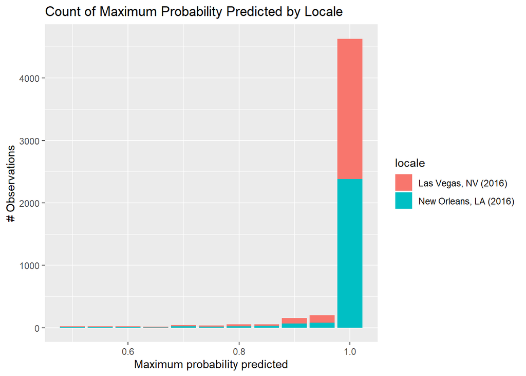

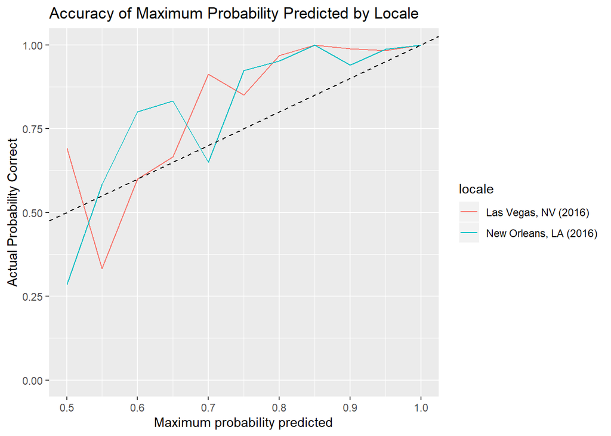

```
## # A tibble: 5,246 x 7
##    `Las Vegas, NV (~ `New Orleans, LA~ maxProb sumProb predClass locale accurate
##                <dbl>             <dbl>   <dbl>   <dbl> <fct>     <fct>  <lgl>
##  1              0.98              0.02    0.98       1 Las Vega~ Las V~ TRUE
##  2              1                 0       1          1 Las Vega~ Las V~ TRUE
##  3              1                 0       1          1 Las Vega~ Las V~ TRUE
##  4              0.98              0.02    0.98       1 Las Vega~ Las V~ TRUE
##  5              1                 0       1          1 Las Vega~ Las V~ TRUE
##  6              1                 0       1          1 Las Vega~ Las V~ TRUE
##  7              1                 0       1          1 Las Vega~ Las V~ TRUE
##  8              1                 0       1          1 Las Vega~ Las V~ TRUE
##  9              1                 0       1          1 Las Vega~ Las V~ TRUE
## 10              1                 0       1          1 Las Vega~ Las V~ TRUE
## # ... with 5,236 more rows
```

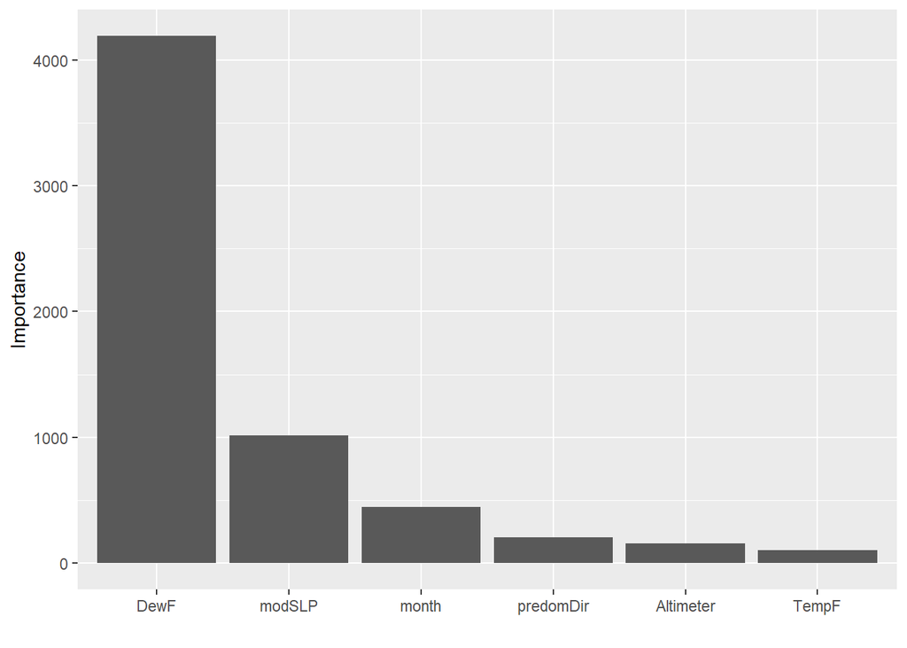

```r
caret::varImp(caretBest) %>%
    rownames_to_column() %>%
    ggplot(aes(x=fct_reorder(rowname, -Overall), y=Overall)) +
    geom_col() +
    labs(x="", y="Importance")
```

The model has greater than 98% accuracy in splitting Las Vegas and New Orleans, driven by 1) New Orleans being extremely humid and Las Vegas being a desert, and 2) New Orleans being at sea level and Las Vegas being at high altitude.

Using modSLP and Altimeter is arguably cheating since the values and relationships between them are highly driven by a location’s height relative to sea-level. How does the model perform if these are deleted?

```r
# Create a tuning grid and run the models
trGrid <- expand.grid(min.node.size=c(1, 5, 10, 25, 100),
                      mtry=c(1, 2, 3, 4),
                      splitrule=c("gini")
                      )

caretModel <- caret::train(locale ~ DewF + month + predomDir + TempF,
                           data=ttLists$trainData,
                           method="ranger",
                           tuneGrid=trGrid,
                           trControl=caret::trainControl(method="cv", number=5),
                           num.trees=50
                           )
caretModel
```

```
## Random Forest
##
## 12242 samples
##     4 predictor
##     2 classes: 'Las Vegas, NV (2016)', 'New Orleans, LA (2016)'
##
## No pre-processing
## Resampling: Cross-Validated (5 fold)
## Summary of sample sizes: 9795, 9793, 9793, 9794, 9793
## Resampling results across tuning parameters:
##
##   min.node.size  mtry  Accuracy   Kappa
##     1            1     0.7760118  0.5520364
##     1            2     0.9124317  0.8248627
##     1            3     0.9327730  0.8655459
##     1            4     0.9500081  0.9000133
##     5            1     0.7602487  0.5204263
##     5            2     0.8996882  0.7993784
##     5            3     0.9323644  0.8647286
##     5            4     0.9480482  0.8960938
##    10            1     0.7947936  0.5895973
##    10            2     0.9154553  0.8309076
##    10            3     0.9313021  0.8626014
##    10            4     0.9465769  0.8931516
##    25            1     0.8033830  0.6068192
##    25            2     0.8972383  0.7944852
##    25            3     0.9300767  0.8601515
##    25            4     0.9462493  0.8924960
##   100            1     0.8175975  0.6352329
##   100            2     0.8979737  0.7959561
##   100            3     0.9250123  0.8500224
##   100            4     0.9345694  0.8691359
##
## Tuning parameter 'splitrule' was held constant at a value of gini
## Accuracy was used to select the optimal model using the largest value.
## The final values used for the model were mtry = 4, splitrule = gini
##  and min.node.size = 1.
```

The model can then be run using the best parameters:

```r
# Run the best parameters from ranger in randomForest
caretBest <- randomForest::randomForest(locale ~ DewF + month + predomDir + TempF,
                                        data=ttLists$trainData,
                                        ntree=50,
                                        nodesize=1,
                                        mtry=4
                                        )
caretBest
```

```
##
## Call:
##  randomForest(formula = locale ~ DewF + month + predomDir + TempF,      data = ttLists$trainData, ntree = 50, nodesize = 1, mtry = 4)
##                Type of random forest: classification
##                      Number of trees: 50
## No. of variables tried at each split: 4
##
##         OOB estimate of  error rate: 3.65%
## Confusion matrix:
##                        Las Vegas, NV (2016) New Orleans, LA (2016) class.error
## Las Vegas, NV (2016)                   5912                    217  0.03540545
## New Orleans, LA (2016)                  230                   5883  0.03762473
```

```r
evalPredictions(caretBest, testData=ttLists$testData)
```

```
## Confusion Matrix and Statistics
##
##                         Reference
## Prediction               Las Vegas, NV (2016) New Orleans, LA (2016)
##   Las Vegas, NV (2016)                   2514                     89
##   New Orleans, LA (2016)                   92                   2551
##
##                Accuracy : 0.9655
##                  95% CI : (0.9602, 0.9703)
##     No Information Rate : 0.5032
##     P-Value [Acc > NIR] : <2e-16
##
##                   Kappa : 0.931
##
##  Mcnemar's Test P-Value : 0.8818
##
##             Sensitivity : 0.9647
##             Specificity : 0.9663
##          Pos Pred Value : 0.9658
##          Neg Pred Value : 0.9652
##              Prevalence : 0.4968
##          Detection Rate : 0.4792
##    Detection Prevalence : 0.4962
##       Balanced Accuracy : 0.9655
##
##        'Positive' Class : Las Vegas, NV (2016)
##
## # A tibble: 2 x 5
##   locale                 meanMax medianMax pct90Plus pct50Minus
##   <fct>                    <dbl>     <dbl>     <dbl>      <dbl>
## 1 Las Vegas, NV (2016)     0.962         1     0.868          0
## 2 New Orleans, LA (2016)   0.971         1     0.900          0
## # A tibble: 11 x 4
##    predProb nCorrect  nObs pctCorrect
##       <dbl>    <int> <int>      <dbl>
##  1     0.5         8    27      0.296
##  2     0.55       12    22      0.545
##  3     0.6        37    64      0.578
##  4     0.65       38    59      0.644
##  5     0.7        62    79      0.785
##  6     0.75       31    50      0.62
##  7     0.8        85   104      0.817
##  8     0.85       80    93      0.860
##  9     0.9       182   194      0.938
## 10     0.95      221   227      0.974
## 11     1        4309  4327      0.996
##
## Mean Error-Squared Between Confidence of Prediction and Accuracy of Precition
## # A tibble: 1 x 1
##   meanError2
##        <dbl>
## 1   0.000589
```

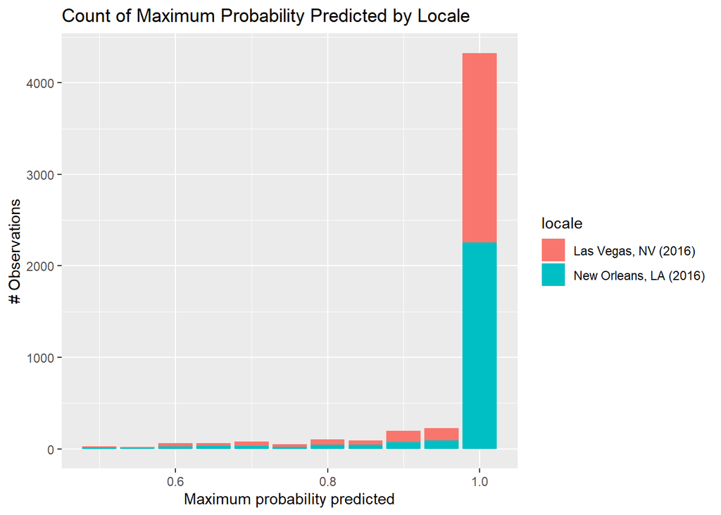

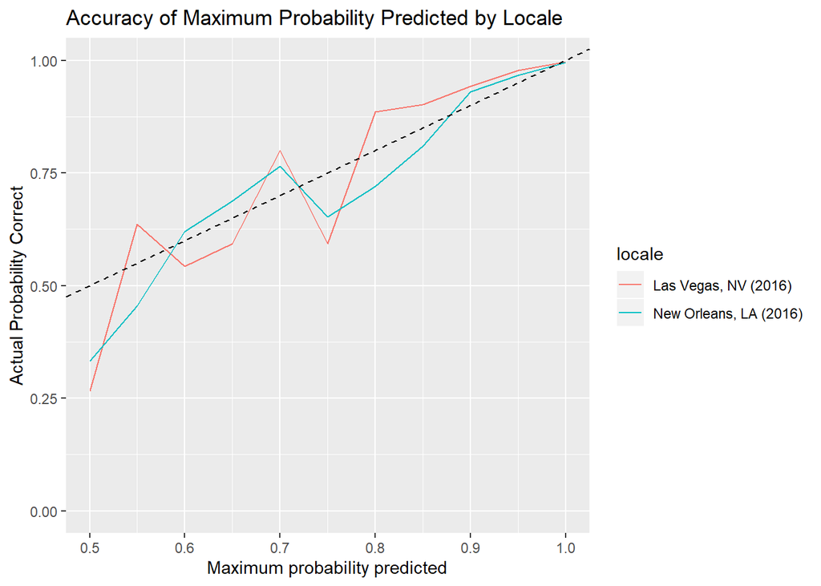

```
## # A tibble: 5,246 x 7
##    `Las Vegas, NV (~ `New Orleans, LA~ maxProb sumProb predClass locale accurate
##                <dbl>             <dbl>   <dbl>   <dbl> <fct>     <fct>  <lgl>
##  1              0.96              0.04    0.96       1 Las Vega~ Las V~ TRUE
##  2              0.96              0.04    0.96       1 Las Vega~ Las V~ TRUE
##  3              1                 0       1          1 Las Vega~ Las V~ TRUE
##  4              1                 0       1          1 Las Vega~ Las V~ TRUE
##  5              1                 0       1          1 Las Vega~ Las V~ TRUE
##  6              1                 0       1          1 Las Vega~ Las V~ TRUE
##  7              1                 0       1          1 Las Vega~ Las V~ TRUE
##  8              1                 0       1          1 Las Vega~ Las V~ TRUE
##  9              1                 0       1          1 Las Vega~ Las V~ TRUE
## 10              1                 0       1          1 Las Vega~ Las V~ TRUE
## # ... with 5,236 more rows
```

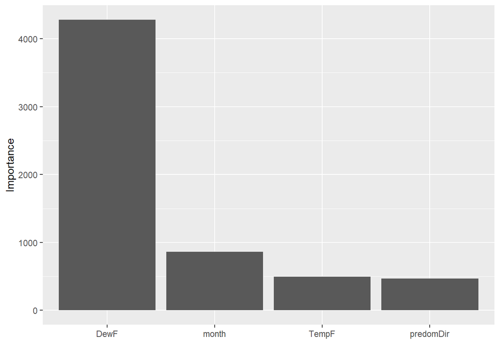

```r
caret::varImp(caretBest) %>%
    rownames_to_column() %>%
    ggplot(aes(x=fct_reorder(rowname, -Overall), y=Overall)) +
    geom_col() +
    labs(x="", y="Importance")
```

The very large difference in dew point drives the high classification ability:

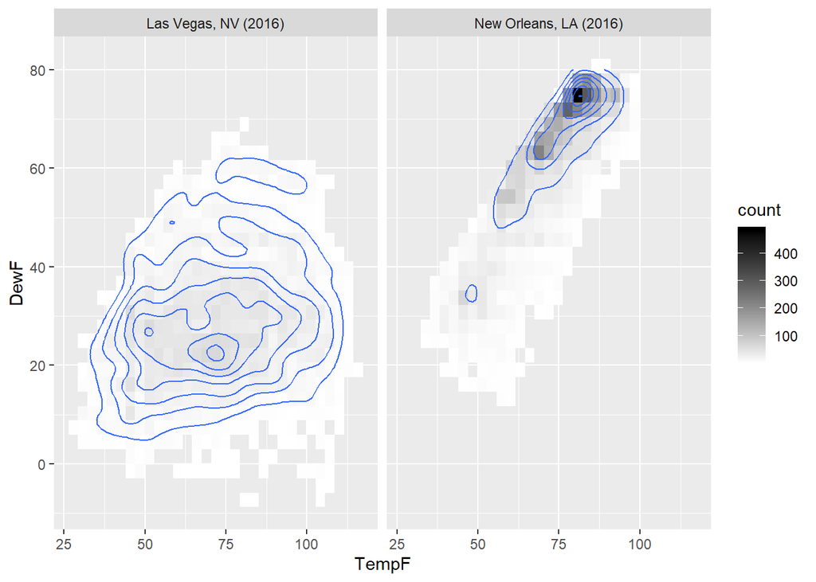

```r
ttLists$trainData %>%
    bind_rows(ttLists$testData) %>%
    ggplot(aes(x=TempF, y=DewF)) +
    geom_bin2d() +
    facet_wrap(~locale) +
    geom_density_2d() +
    scale_fill_continuous(low="white", high="black")
```

Suppose on the other hand that the model tries to distinguish New Orleans from Houston:

```r
ttLists <- createTestTrain(metarData,
                           sources=c("kiah_2016", "kmsy_2016"),
                           vrbls=c("locale", "month", "predomDir", "TempF", "DewF"),
                           seed=2006181440
                           )
ttLists
```

```
## $testData
## # A tibble: 5,248 x 5
##    locale             month predomDir TempF  DewF
##    <fct>              <fct> <fct>     <dbl> <dbl>
##  1 Houston, TX (2016) Jan   N          53.1  39.9
##  2 Houston, TX (2016) Jan   N          52.0  39.9
##  3 Houston, TX (2016) Jan   N          48.0  42.1
##  4 Houston, TX (2016) Jan   N          48.0  35.1
##  5 Houston, TX (2016) Jan   N          48.0  35.1
##  6 Houston, TX (2016) Jan   N          48.9  35.1
##  7 Houston, TX (2016) Jan   N          48.0  35.1
##  8 Houston, TX (2016) Jan   N          48.0  37.0
##  9 Houston, TX (2016) Jan   N          46.9  39.0
## 10 Houston, TX (2016) Jan   N          45.0  37.0
## # ... with 5,238 more rows
##
## $trainData
## # A tibble: 12,245 x 5
##    locale                 month predomDir TempF  DewF
##    <fct>                  <fct> <fct>     <dbl> <dbl>
##  1 New Orleans, LA (2016) Dec   N          53.1  37.9
##  2 Houston, TX (2016)     Oct   S          75.9  71.1
##  3 Houston, TX (2016)     Oct   NE         73.0  44.1
##  4 New Orleans, LA (2016) May   N          72.0  55.9
##  5 New Orleans, LA (2016) Aug   S          78.1  72.0
##  6 Houston, TX (2016)     Jun   000        78.1  75.0
##  7 Houston, TX (2016)     Mar   000        54.0  53.1
##  8 Houston, TX (2016)     Oct   N          81.0  46.0
##  9 New Orleans, LA (2016) Dec   SW         80.1  64.9
## 10 Houston, TX (2016)     Sep   S          84.0  78.1
## # ... with 12,235 more rows
```